# ALS MotorNeuron Proteomics Analysis

## Loading Data

The data set contains measurements from ALS and control groups, with 18 individual cells from each group (6 cells each from 3 donors per group). We also have a larger “boost” sample the consisted of a pool of ten single cells – these data were used to facilitate a match-between-runs algorithm for increased assignment of peptide-spectrum-matches.

```r
library(dplyr)
```

```r
library(ggplot2)
library(knitr)
library(tidyverse)
library(DEP)
library(SummarizedExperiment)
set.seed(2)

setwd("~/Library/CloudStorage/OneDrive-Biogen/single cell proteomics/ALS_MotorNeurons")

main.dir<-"/Users/stjhc/Library/CloudStorage/OneDrive-Biogen/single cell proteomics/ALS_MotorNeurons"

samples<-read.csv(paste(main.dir, "/Sample_sheet.csv", sep=""))
sc.pr<-read.csv(paste(main.dir,"/2022_01_13_nanoPOTS_SingleMN_ALS_Pilot_Dataset_for_JenHwa_and_Jake.csv", sep=""))
sc.pr.norm<-sc.pr[,c(5,25,73:114)]
colnames(sc.pr.norm)[3:44]<-samples$Sample
```

## Data Preparation

Following the vignettes (https://bioconductor.org/packages/devel/bioc/vignettes/DEP/inst/doc/DEP.html), we created a SummarizedExperiment object.

```r
sc.pr.norm$Gene.Symbol %>% duplicated() %>% any()
```

```
## [1] TRUE
```

```r
sc.pr.norm %>% group_by(Gene.Symbol) %>% summarize(frequency = n()) %>%
  arrange(desc(frequency)) %>% filter(frequency > 1)
```

```
## # A tibble: 1 × 2
##   Gene.Symbol frequency
##   <chr>           <int>
## 1 ""                  3
```

```r
sc.pr.unique <- make_unique(sc.pr.norm, "Gene.Symbol", "Accession", delim = ";")


label<-samples$Sample

F_columns <- grep("F", colnames(sc.pr.unique))

condition<-samples$Donor.Code
replicate<-samples$replicate
ExpDesign<-cbind(label, condition,replicate)
ExpDesign<-data.frame(ExpDesign)

boost<-which(samples$Randomizer=="Boost")
F_columns <-F_columns[-boost]
ExpDesign<-ExpDesign[-boost,]
sc.pr.se <- make_se(sc.pr.unique, F_columns, ExpDesign)
```

## Filter on Missing Values

We plot the frequency of missing values over samples. We filtered out the proteins that with 3 or more missing values in at least one condition. After filtering, 1,375 out of 2,752 proteins (50%) were removed from the anlysis. We also plotted the number of identified proteins per samples. Overall this data set contains a lot of missing values, with about 60% of the data missing. One sample (F22) has over 90% of the data missing and is removed from the analysis.

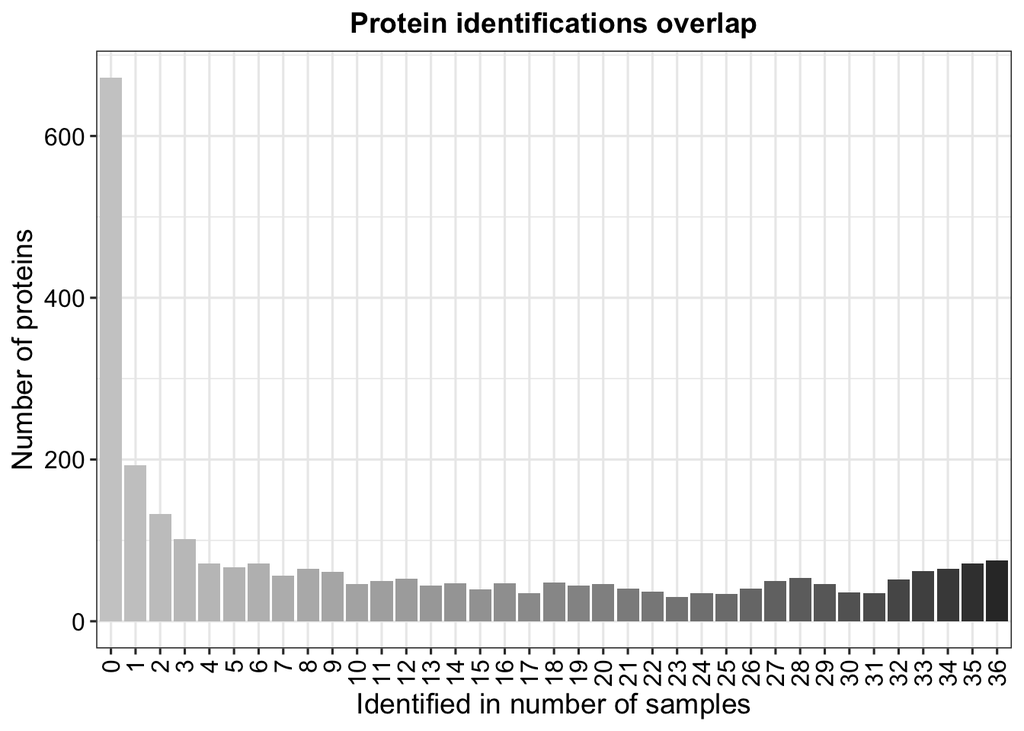

```r
plot_frequency(sc.pr.se)
```

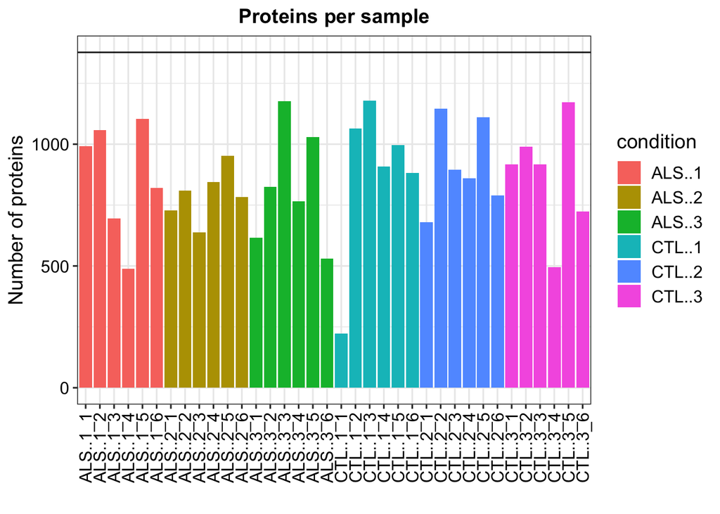

```r
sc.pr.filt <- filter_missval(sc.pr.se, thr = 3)
plot_numbers(sc.pr.filt)
```

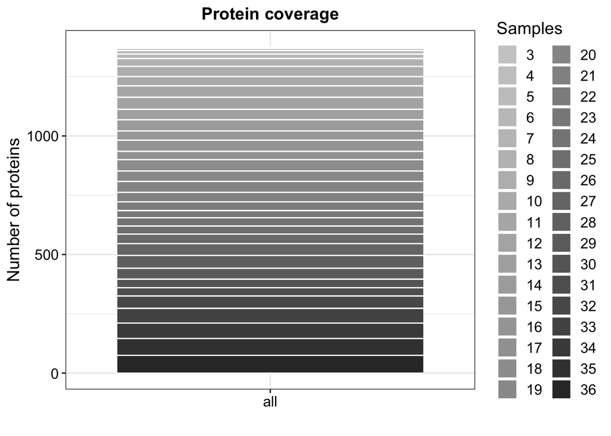

```r
plot_coverage(sc.pr.filt)
```

```r
colData(sc.pr.filt)$condition<-samples$Diagnosis[-boost]
colData(sc.pr.filt)$replicate<-samples$Donor.Code[-boost]


sc.pr.filt<-sc.pr.filt[,-which(colData(sc.pr.filt)$label=="F22")]
```

## Normalization

The data is background corrected and normalized by variance stabilizing transformation (vsn). The distribution of all samples before and after normalization are shown here.

Note: The variance stabilizing transformation method, which was developed for microarray data to remove the dependency of variance from the mean (heteroscedasticity), seems to work well for proteomic data too (See Välikangas et al, PMID: 27694351)

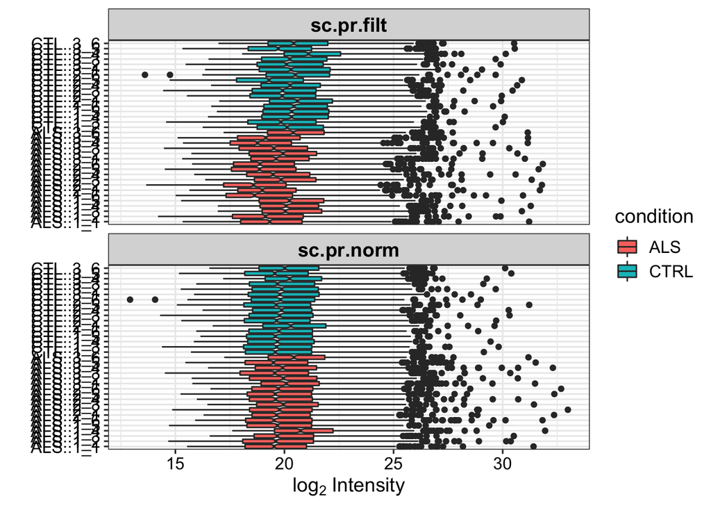

```r
sc.pr.norm <- normalize_vsn(sc.pr.filt)
plot_normalization(sc.pr.filt, sc.pr.norm)
```

# Imputation

The missing data was imputed. First we inspected the pattern of missing data though a heatmap. We also compared intensity distributions and cumulative fraction of proteins with and without missing values.

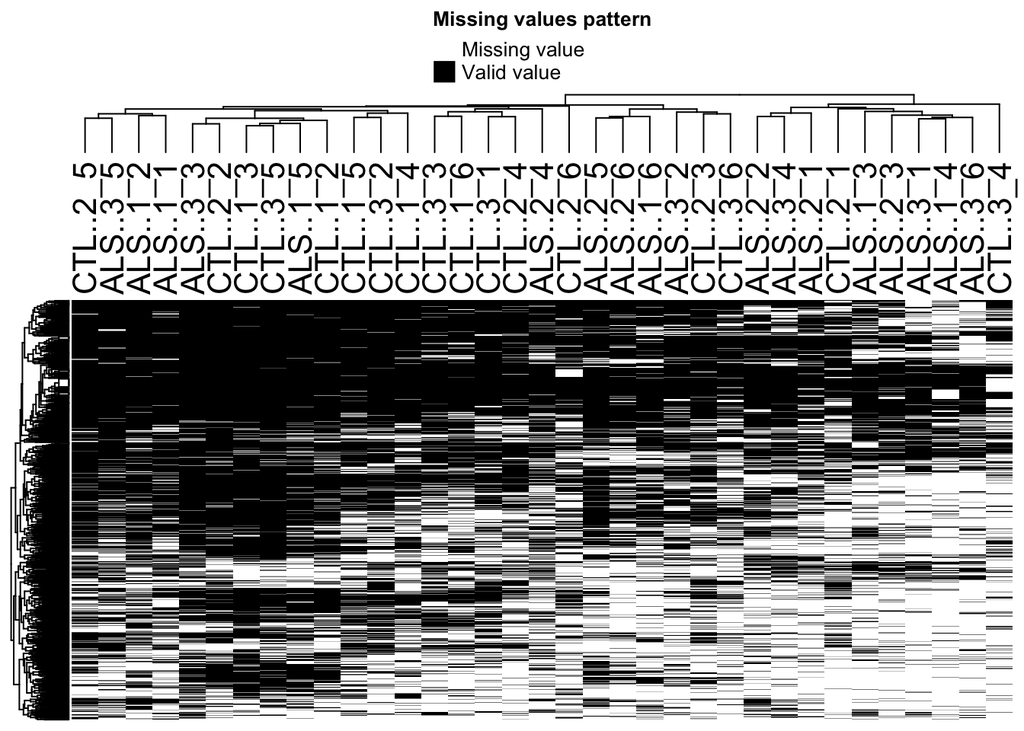

```r
plot_missval(sc.pr.filt)
```

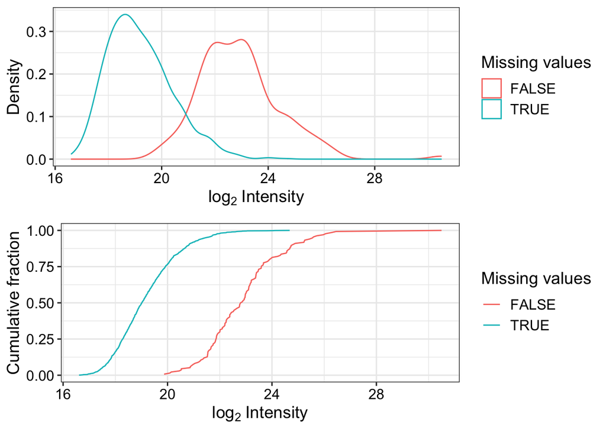

```r
plot_detect(sc.pr.filt)
```

```r
sc.pr.imp <- impute(sc.pr.filt, fun = "MinProb", q = 0.05)
```

```
## [1] 1.308804
```

```r
sc.pr.imp2 <- impute(sc.pr.filt, fun = "MinProb", q = 0.01)
```

```
## [1] 1.308804
```

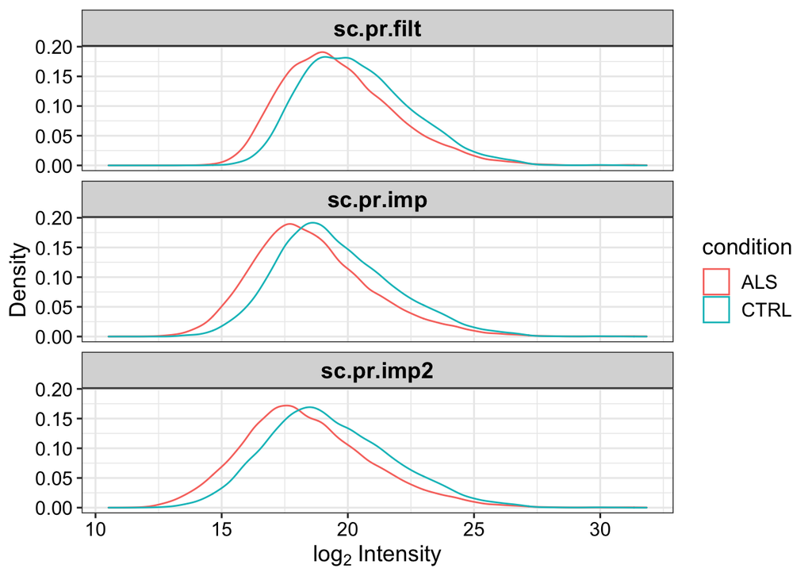

```r
plot_imputation(sc.pr.filt, sc.pr.imp, sc.pr.imp2)
```

#Differential Expression

```r
library(limma)
```

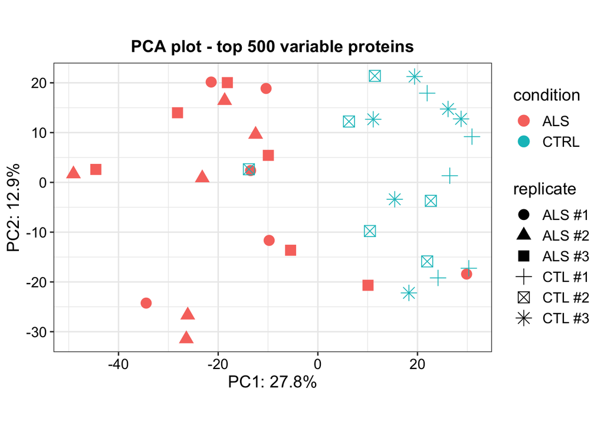

```r
se<-sc.pr.imp
design_formula = formula(~0 + condition)
control = "CTRL"

col_data <- colData(se)
raw <- assay(se)

design <- model.matrix(design_formula, data = col_data)
colnames(design) <- gsub("condition", "", colnames(design))
conditions <- as.character(unique(col_data$condition))
cntrst <- paste(conditions[!conditions %in% control],
                control, sep = " - ")

corfit <- duplicateCorrelation(raw,design,block=col_data$replicate)

fit <- lmFit(raw, design = design, block=col_data$replicate,correlation=corfit$consensus)
made_contrasts <- makeContrasts(contrasts = cntrst, levels = design)
contrast_fit <- contrasts.fit(fit, made_contrasts)

eB_fit <- eBayes(contrast_fit)
retrieve_fun <- function(comp, fit = eB_fit) {
  res <- topTable(fit, sort.by = "t", coef = comp, number = Inf,
                  confint = TRUE)
  res <- res[!is.na(res$t), ]
  fdr_res <- fdrtool::fdrtool(res$t, plot = FALSE, verbose = FALSE)
  res$qval <- fdr_res$qval
  res$lfdr <- fdr_res$lfdr
  res$comparison <- rep(comp, dim(res)[1])
  res <- rownames_to_column(res)
  return(res)
}
limma_res <- map_df(cntrst, retrieve_fun)
table <- limma_res %>% select(rowname, logFC, CI.L, CI.R, P.Value, adj.P.Val, comparison) %>%
  mutate(comparison = gsub(" - ",  "_vs_", comparison)) %>%
  gather(variable, value, -c(rowname,comparison))  %>%
  mutate(variable = recode(variable, logFC = "diff", P.Value = "p.val", adj.P.Val = "p.adj"))  %>%
  unite(temp, comparison, variable) %>% spread(temp, value)

rowData(se) <- merge(rowData(se, use.names = FALSE), table,
                     by.x = "name", by.y = "rowname", all.x = TRUE, sort = FALSE)

sc.pr.diff<-se
dep <- add_rejections(sc.pr.diff, alpha = 0.05, lfc = log2(1.5))
plot_pca(dep, x = 1, y = 2, n = 500, point_size = 4)
```

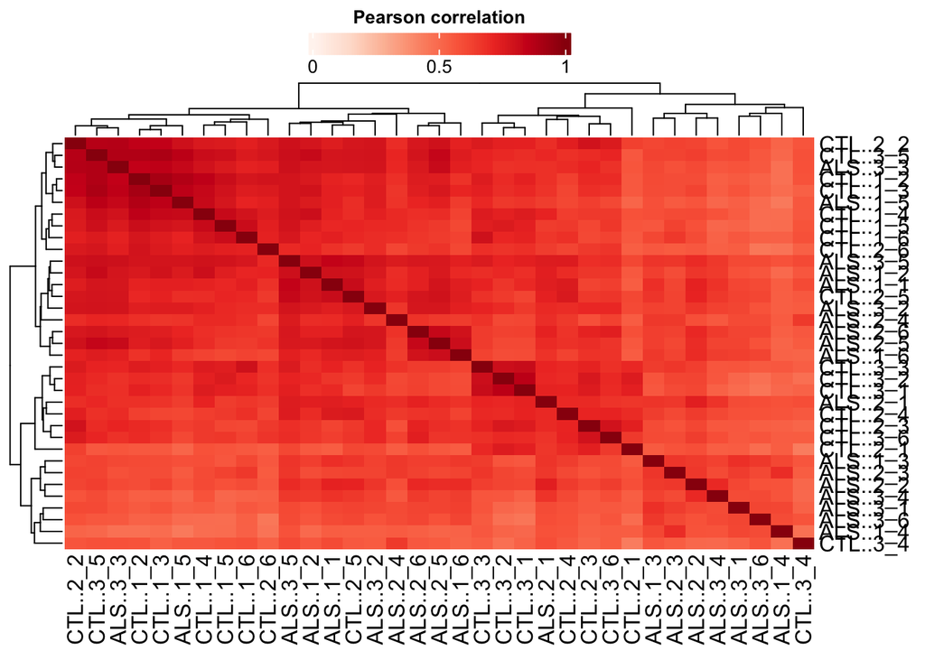

```r
plot_cor(dep, significant = TRUE, lower = 0, upper = 1, pal = "Reds")
```

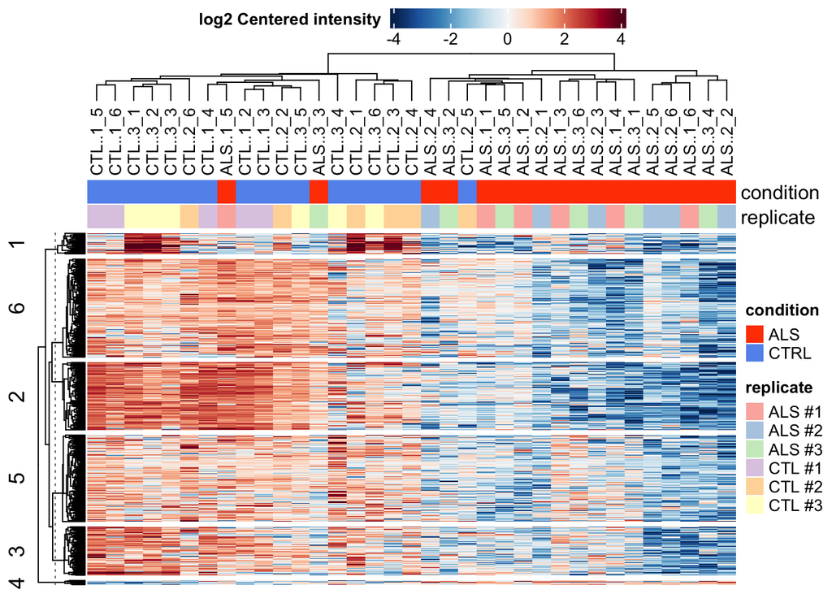

```r
plot_heatmap(dep, type = "centered", kmeans = TRUE,
             k = 6, col_limit = 4, show_row_names = FALSE,
             indicate = c("condition", "replicate"))
```

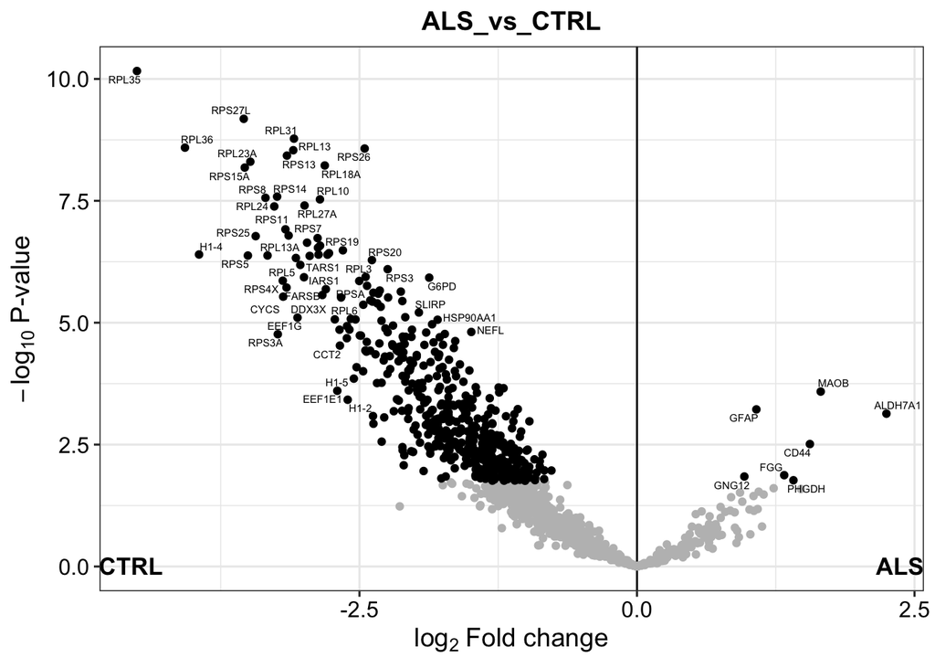

```r
plot_volcano(dep, contrast = "ALS_vs_CTRL", label_size = 2, add_names = TRUE)
```

#Donor Information

We repeated the differential expression analysis after adjusting for the donor infirmation, including age, sex and post mortem intervals (PMI, hours). After adjusting for donor information, only a small number of DE proteins remain.

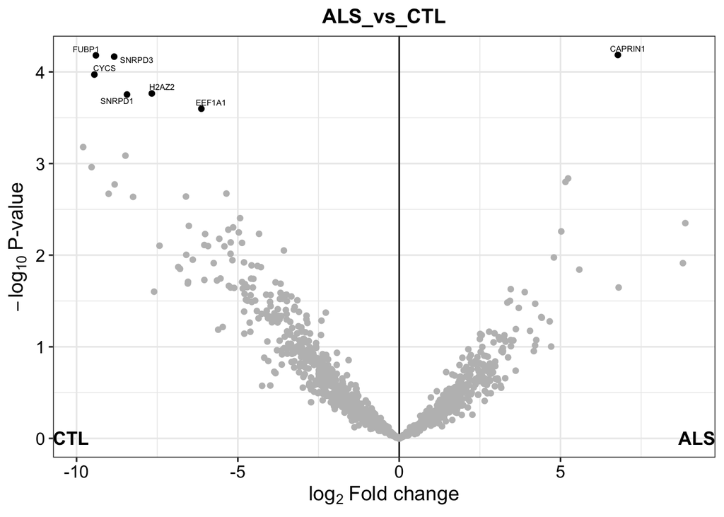

```r
donor.info<-read.csv(paste(main.dir,"/2022_02_23_nanoPOTS_SingleMN_ALS_Pilot_Dataset_for_JenHwa_and_Jake_Donor_Potential_Covariates.csv", sep=""))

colData(sc.pr.imp)$condition<-rep(c("ALS","CTL"), c(18,17))
colData(sc.pr.imp)$replicate<-rep(c("ALS #1","ALS #2","ALS #3","CTL #1","CTL #2","CTL #3"), c(6,6,6,5,6,6))

all.donor.info<-merge(colData(sc.pr.imp), donor.info, by.x="replicate", by.y="Donor_Code", all.x=TRUE, sort=FALSE)

colData(sc.pr.imp)$PMI<-all.donor.info$PMI
colData(sc.pr.imp)$Age<-all.donor.info$Age
colData(sc.pr.imp)$Sex<-as.factor(all.donor.info$Sex)

se<-sc.pr.imp
design_formula = formula(~0 + condition + PMI + Age + Sex)
control = "CTL"
col_data <- colData(se)
raw <- assay(se)

design <- model.matrix(design_formula, data = col_data)
colnames(design) <- gsub("condition", "", colnames(design))
conditions <- as.character(unique(col_data$condition))
cntrst <- paste(conditions[!conditions %in% control],
                control, sep = " - ")

corfit <- duplicateCorrelation(raw,design,block=col_data$replicate)

fit <- lmFit(raw, design = design, block=col_data$replicate,correlation=corfit$consensus)
made_contrasts <- makeContrasts(contrasts = cntrst, levels = design)
contrast_fit <- contrasts.fit(fit, made_contrasts)

eB_fit <- eBayes(contrast_fit)

limma_res <- map_df(cntrst, retrieve_fun)
table <- limma_res %>% select(rowname, logFC, CI.L, CI.R, P.Value, adj.P.Val, comparison) %>%
  mutate(comparison = gsub(" - ",  "_vs_", comparison)) %>%
  gather(variable, value, -c(rowname,comparison))  %>%
  mutate(variable = recode(variable, logFC = "diff", P.Value = "p.val", adj.P.Val = "p.adj"))  %>%
  unite(temp, comparison, variable) %>% spread(temp, value)

rowData(se) <- merge(rowData(se, use.names = FALSE), table,
                     by.x = "name", by.y = "rowname", all.x = TRUE, sort = FALSE)

sc.pr.diff<-se
dep <- add_rejections(sc.pr.diff, alpha = 0.05, lfc = log2(1.5))
#plot_pca(dep, x = 1, y = 2, n = 500, point_size = 4)
#plot_cor(dep, significant = TRUE, lower = 0, upper = 1, pal = "Reds")
#plot_heatmap(dep, type = "centered", kmeans = TRUE,
#             k = 6, col_limit = 4, show_row_names = FALSE,
#             indicate = c("condition", "replicate"))
plot_volcano(dep, contrast = "ALS_vs_CTL", label_size = 2, add_names = TRUE)
```